# Who Holds the Seats? Women in Local Government

A scrollytelling exercise

# Scrollytelling with maps

*Christophe Bontemps (SIAP) - Version 1.5 (2026)*

*Scrollytelling* combines narrative text with interactive maps to reveal information progressively as the reader scrolls. By synchronizing map movements and visual changes with the story, it helps audiences explore complex geographic data in a clear and engaging way.

In this demo, we will see how scrollytelling can guide readers through a complex choropleth map representing Women in local governments all over the world, highlighting key locations and insights step by step, region by region.

> Just scroll down!

Across the 146 countries with reported data, the share of women in local government ranges from under **2%** to over **50%**.

The map uses a **diverging classification palette** centered on 30%: countries below shade toward red, countries above shade toward blue. Grey means no elected local government body, or no data reported.

This single choice already does a lot of storytelling: *Different choices would draw the eye somewhere else*.

No single global pattern jumps out immediately — high and low values are scattered across regions rather than clustered in one place.

Let’s do something else.

Ordering **subregions** by their median value (cross), and coloring each country with the same red-to-blue spread provides a regional focus and **reveals some patterns**, while highlighting the **diversity** within subregions.

Let’s focus on the upper part of the table specifically.

Even in regions with a good proportion of women in local governmental bodies, the **diversity** of values is striking (*e.g.* Melanesia).

Let’s go back to the map and have a closer look by region.

Let’s start with **Africa** first.

Zooming into Africa: **Benin** (3.5%) and **Ghana** (3.8%) rank among the lowest anywhere in the dataset, while **Rwanda** (43.6%), **Namibia** (44.9%) and **Senegal** (47.2%), sit close to parity.

Eight African countries in this dataset — including Egypt, Somalia, and Sudan — report no elected local government body at all, shown here in grey.

Now let’s turn to **Asia and the Pacific**, home of ESCAP.

Let’s zoom in a second time, further into **the Pacific** specifically.

**Micronesia** (1.5%), **Kiribati (7.3%)** and **Vanuatu** (10.1%) report some of the lowest shares in the entire dataset.

**Fiji** (35.8%) and **New Caledonia** (47.2%) sit at the other end of the regional range, a reminder that “the Pacific” is not one story, but many.

Zooming back to the map highlights the difficulty of exploring this information only through a map where countries with large areas are largely over represented.

This is the most important limitation of Choropleth maps. Interactivity here helps reading and highlighting countries with low rates, and thus telling a story, but would not help in exploring the data and finding these stories.

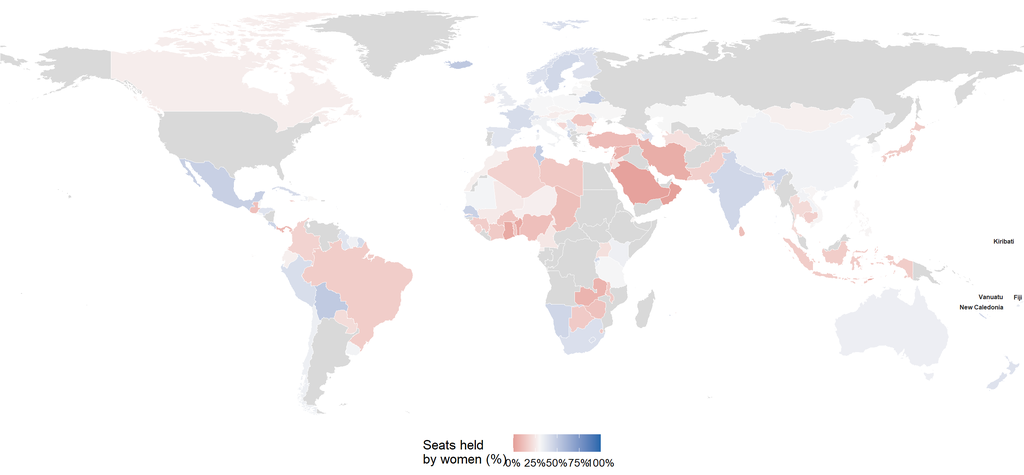

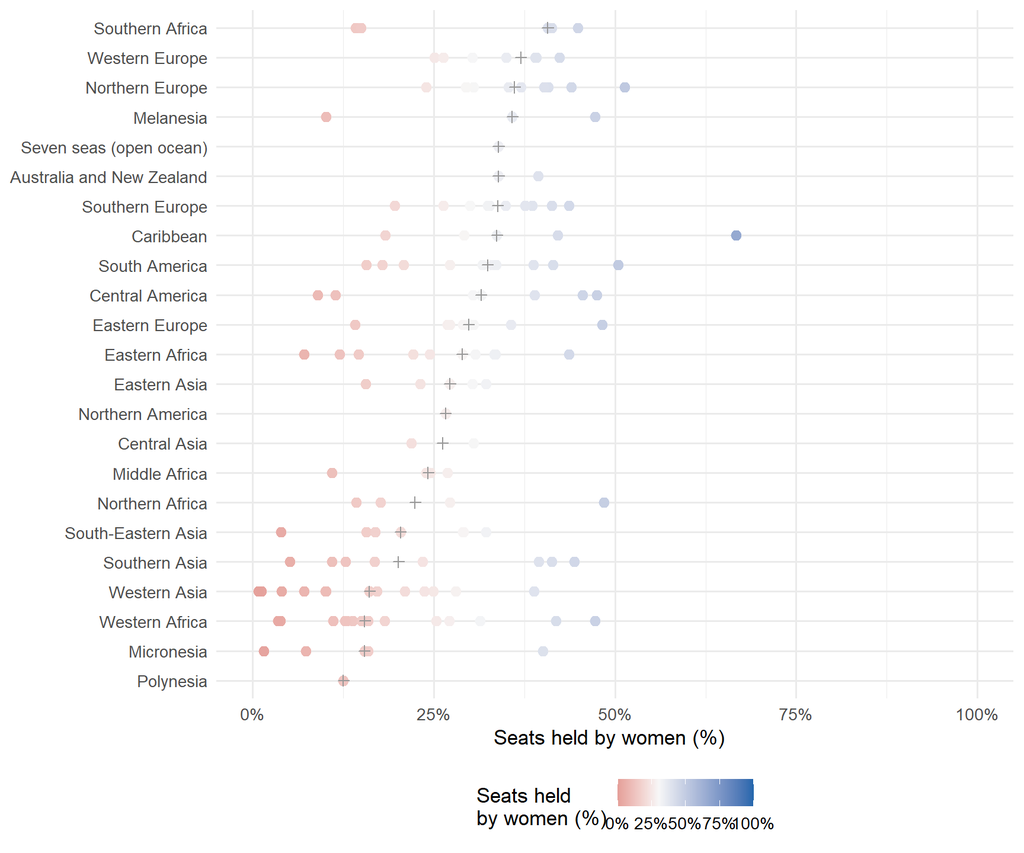

# To conclude

Scrollytelling with maps offer a powerful way to combine narrative, data, and geography into a single interactive experience. By synchronizing movements on a map (zooming, panning, highlighting) with explanatory text, they guide readers through complex spatial information in a clear and engaging way.

Effective scrollytelling is not simply about adding animation. Rather, it is about using animation and data visualization to support a compelling narrative, draw attention to key insights, and help the audience develop a deeper understanding of the information being presented.

This demo has been created using *closeread* with R code (maps) and a *quarto* notebook.